# MP01_Part01_ToothGrowthData

Jalal Mansoori

11/8/2020

## Exploratory Data Analysis

```r
#loading necessary packages
library(tidyverse)
#loading ToothGrowth dataset
data("ToothGrowth")
# Getting info about internal structure of the data
str(ToothGrowth)
```

```
## 'data.frame':    60 obs. of  3 variables:
##  $ len : num  4.2 11.5 7.3 5.8 6.4 10 11.2 11.2 5.2 7 ...
##  $ supp: Factor w/ 2 levels "OJ","VC": 2 2 2 2 2 2 2 2 2 2 ...
##  $ dose: num  0.5 0.5 0.5 0.5 0.5 0.5 0.5 0.5 0.5 0.5 ...
```

## Description

Title: The Effect of Vitamin C on Tooth Growth in Guinea Pigs

In ToothGrowth dataset we have 60 observations and 3 variables and each observation consists information about the measure of:

1. len: Length of Tooth
2. supp: Vitamin C Supplement given to each animal in the form of Orange juice(OJ) or ascorbic acid (VC)
3. dose: The amount of dose levels of Vitamin C (0.5, 1, 2) in milligrams/day

Now let’s get started

```r
#Getting first few values in ToothGrowth Data
head(ToothGrowth)
```

```
##    len supp dose
## 1  4.2   VC  0.5
## 2 11.5   VC  0.5
## 3  7.3   VC  0.5
## 4  5.8   VC  0.5
## 5  6.4   VC  0.5
## 6 10.0   VC  0.5
```

##Univariate analysis

How many animals received Supplement of Vitamin C in the form of orange juice and ascorbic acid?

```r
ToothGrowth %>%
  group_by(supp) %>% count(supp)
```

```
## # A tibble: 2 x 2
## # Groups:   supp [2]
##   supp      n
##   <fct> <int>
## 1 OJ       30
## 2 VC       30
```

50% of total animals in ToothGrowth dataset received Vitamin C in the form of Orange Juice (OJ) and Other 50% received Vitamin C in the form of ascorbic acid (VC)

Summary Statistics of Tooth Length

```r
summary(ToothGrowth$len)
```

```
##    Min. 1st Qu.  Median    Mean 3rd Qu.    Max.
##    4.20   13.07   19.25   18.81   25.27   33.90
```

Above summary statistics suggests that:

1. 50% of Tooth Length is below and above 19.25 (Median) (2nd Quartile)
2. The Average length is 18.81 (Mean)
3. 25% of Tooth Length is below 13.07 (1st Quartile)
4. 75% of Tooth Length is below 25.27 (3rd Quartile)
5. Min length is 4.20 and Max length is 33.90

## Plotting the distribution of Tooth Length Using Box Plot

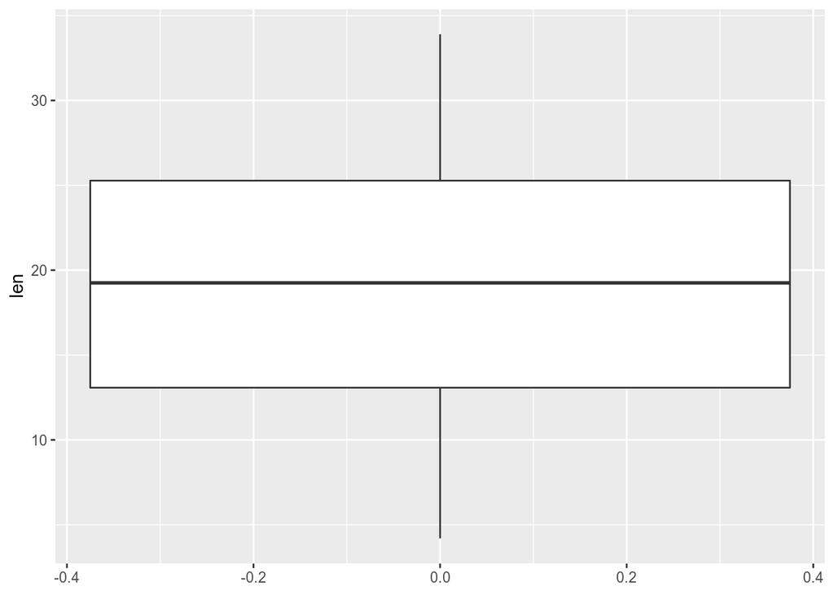

```r
ggplot(data= ToothGrowth, aes(y = len)) +
  geom_boxplot()
```

## Plotting the distribution of Tooth Length using Histogram

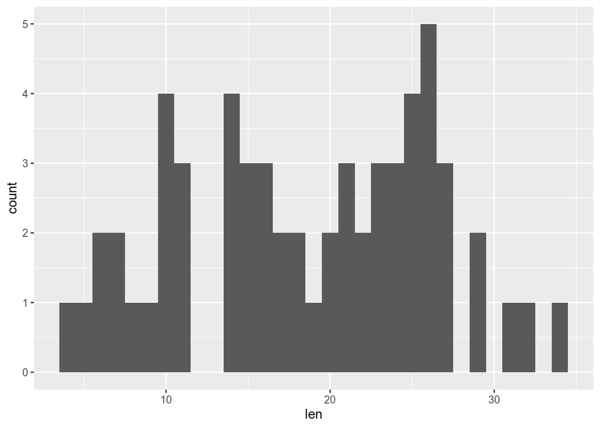

```r
ggplot(data=ToothGrowth, aes(x=len)) +
geom_histogram(binwidth = 1)
```

## Bivariate Analysis

Average Tooth Length based on the given Supplement type OJ or VC

```r
ToothGrowth %>%
  group_by(supp) %>%
  summarise(Avg_Tooth_Length = mean(len), Standard_deviation=sd(len))
```

```
## # A tibble: 2 x 3
##   supp  Avg_Tooth_Length Standard_deviation
##   <fct>            <dbl>              <dbl>
## 1 OJ                20.7               6.61
## 2 VC                17.0               8.27
```

## Ploting Distribution of Tooth Length based on Supplement using Box plot

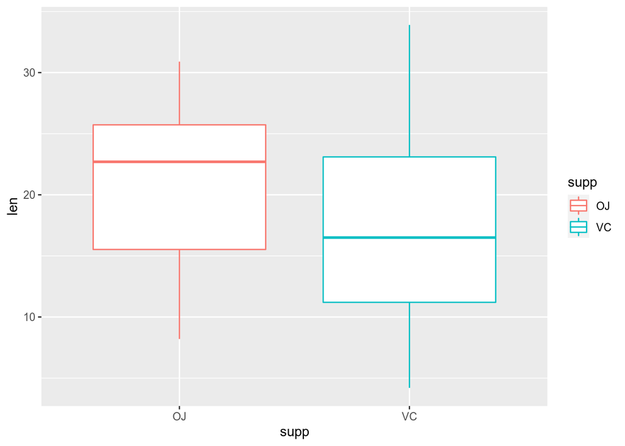

```r
ggplot(data=ToothGrowth , aes(x=supp, y=len, color=supp)) +
  geom_boxplot()
```

```r
ToothGrowth %>%
  group_by(dose) %>%
  summarise(Avg_Tooth_Length = mean(len))
```

```
## # A tibble: 3 x 2
##    dose Avg_Tooth_Length
##   <dbl>            <dbl>
## 1   0.5             10.6
## 2   1               19.7
## 3   2               26.1
```

Summary table suggests that the average tooth length is greater in the animals that received 2 level dose of Vitamin C

We can also plot the distribution of Tooth length with respect to dose variable using side by side box plot. For that first we need to convert the data type of dose from numeric to factor

```r
#Converting dose data type from numeric to factor
ToothGrowth$dose <- as.factor(ToothGrowth$dose)
```

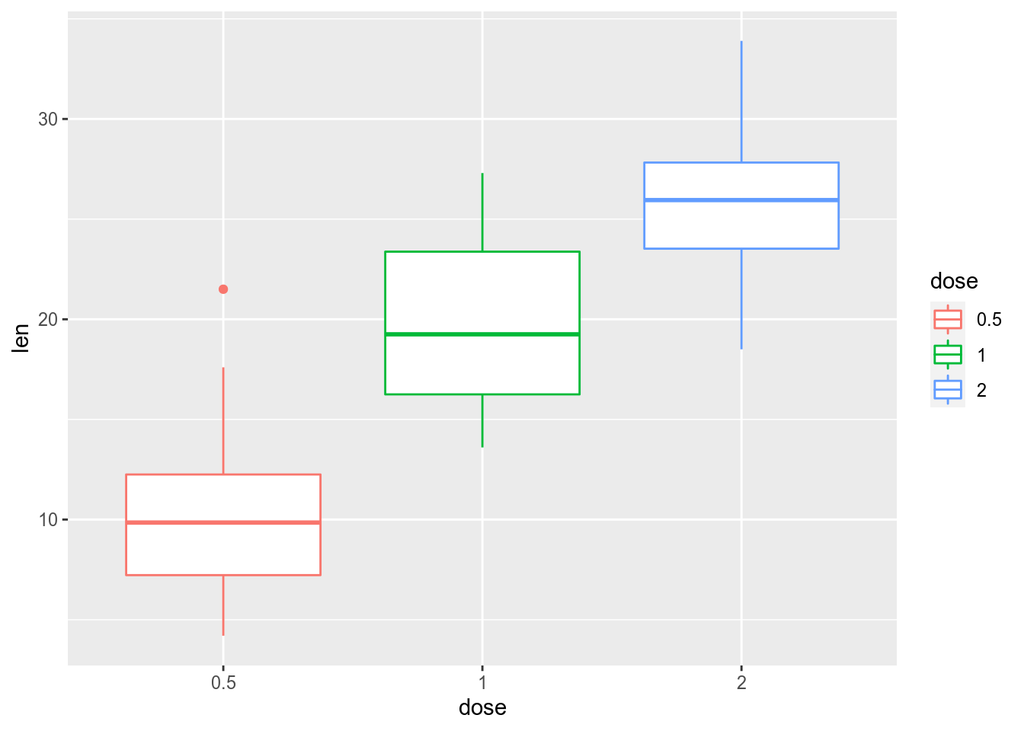

```r
ggplot(ToothGrowth, aes(x=dose, y=len, color=dose)) +
  geom_boxplot()
```

In above side by side box plot we can see only one outlier in the observations who received 0.5 level of dose. 50% of tooth length is greater than or below approx 10 in 0.5 dose level 50% of tooth length is greater than or below approx 19 in 1 dose level 50% of tooth length is greater than or below approx 26 in 2 dose level

## Confidence Interval

Objective is to compare the mean tooth length of animals based on the supplement given i.e Orange juice or ascorbic acid. So first we’ll calculate the 95% confidence interval for true population mean of tooth length with respect to Orange Juice Supplement and then for ascorbic acid

```r
#Calculating the Sample mean and Sample Standard deviation of Tooth Length With respect to given Supplement type

ToothGrowth %>%
  group_by(supp) %>%
  summarise(Avg_Tooth_Length = mean(len), Standard_deviation=sd(len))
```

```
## # A tibble: 2 x 3
##   supp  Avg_Tooth_Length Standard_deviation
##   <fct>            <dbl>              <dbl>
## 1 OJ                20.7               6.61
## 2 VC                17.0               8.27
```

```r
# Calculating 95% Confidence Interval for True Population mean of animals Tooth length that were given orange juice

#Sampling observations that were given Orange Juice

sample_OJ <- ToothGrowth %>%
  filter(supp=='OJ')

Standard_Err_OJ <- sd(sample_OJ$len)/ sqrt(length(sample_OJ$len))

#Confidence Interval using t distribution
mean(sample_OJ$len) + c(-1,1)*qt(0.975, df= length(sample_OJ$len) - 1 ) * Standard_Err_OJ
```

```
## [1] 18.19678 23.12989
```

We are 95% Confident that the true population mean of Animals Tooth Length that were given Orange Juice Supplement is between 18.2 % and 23.1%

Now calculating 95% Confidence Interval for True Population mean of animals Tooth length that were given ascorbic acid

```r
#Sampling observations that were given Orange Juice

sample_VC <- ToothGrowth %>%
  filter(supp=='VC')

Standard_Err_VC <- sd(sample_VC$len)/ sqrt(length(sample_VC$len))

#Confidence Interval using t distribution
mean(sample_VC$len) + c(-1,1)*qt(0.975, df= length(sample_VC$len) - 1 ) * Standard_Err_VC
```

```
## [1] 13.87675 20.04992
```

We are 95% Confident that the true population mean of Animals Tooth Length that were given ascorbic acid Supplement is between 14% % and 20.0%

So if we compare the confident intervals of both supplements then it’s more likely that animals that were given Vitamin C in the form of Orange Juice has plausible range of Greater Tooth Length